# IODS course project

## k-means algorithm with varying numbers of clusters (k)

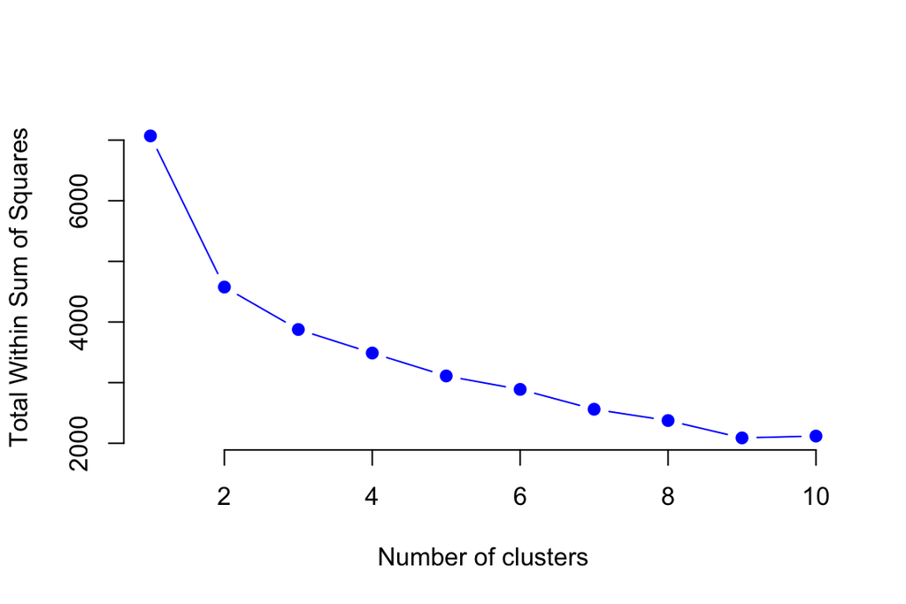

```r
# Determine the number of clusters
k_max <- 10

# Calculate total within-cluster sum of squares (TWSS) for different cluster numbers
twss <- sapply(1:k_max, function(k) kmeans(boston_scaled, centers = k)$tot.withinss)

# Visualize the TWSS
plot(1:k_max, twss, type = "b", pch = 19, frame = FALSE, col = "blue", xlab = "Number of clusters", ylab = "Total Within Sum of Squares")
```

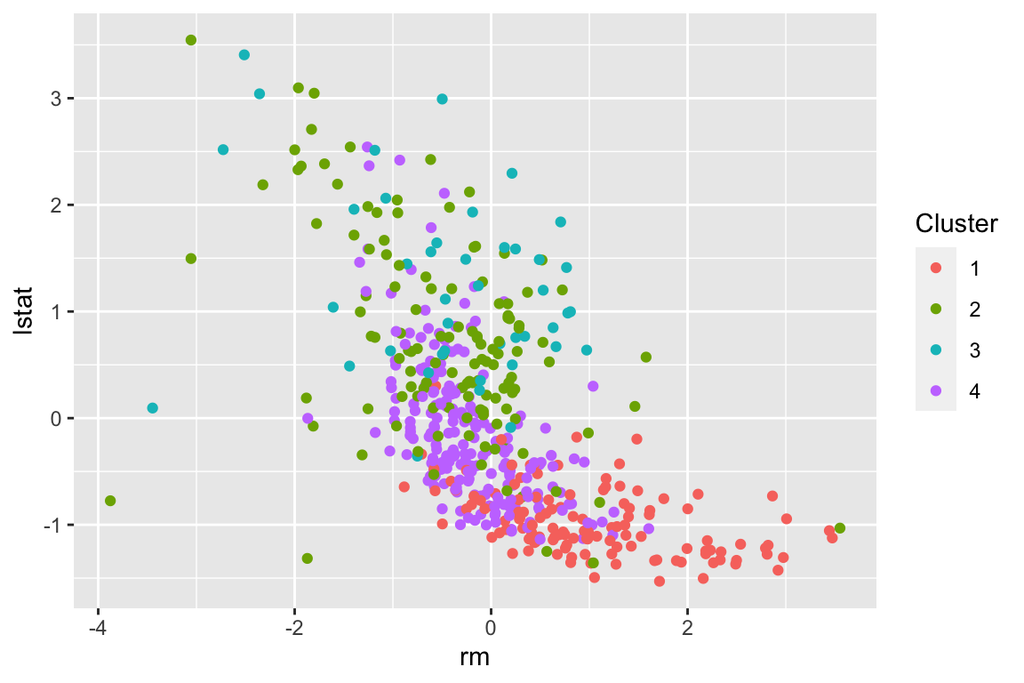

```r
# Choose the optimal number of clusters
optimal_clusters <- 4

# Run k-means with the optimal number of clusters
kmeans_result <- kmeans(boston_scaled, centers = optimal_clusters)

# Creating a data frame for plotting
plot_data <- as.data.frame(boston_scaled)
plot_data$cluster <- factor(kmeans_result$cluster)

# Visualize clusters using pairs() with colors
ggplot(plot_data, aes(x = rm, y = lstat)) +
  geom_point(aes(color = cluster)) +
  labs(color = 'Cluster')
```

**Cluster Distribution:** The plot shows how the observations are grouped into four different clusters. Each cluster is represented by a different color.

**Cluster 1:** Higher `rm` and moderate to low `lstat` values, indicating larger houses with a lower proportion of lower-status population.

**Cluster 3:** Reflects neighborhoods with smaller homes (low `rm``) where the community leans towards a higher percentage of lower-status residents.

**Cluster 4:** Moderate `rm` values and `lstat` values, indicating that the average-sized rooms with a moderate lower-status population.

**Correlation Inference:** The negative correlation between the number of rooms (`rm`) and the percentage of lower-status population (`lstat`) aligns with our expectations. In areas with more rooms, there tends to be a lower percentage of lower-status residents.

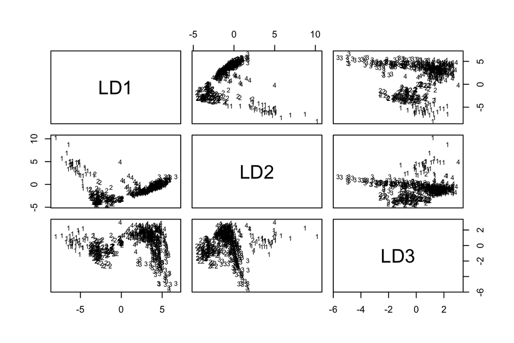

```r
# Standardize the original Boston dataset
original_boston_scaled <- as.data.frame(scale(Boston))

# Perform k-means with some reasonable number of clusters
reasonable_clusters <- 4
kmeans_original <- kmeans(original_boston_scaled, centers = reasonable_clusters)

# Perform LDA using the clusters as target classes
lda_fit <- lda(kmeans_original$cluster ~ ., data = original_boston_scaled)

# Visualize LDA results with a biplot
plot(lda_fit)
```

```r
lda_fit$scaling
```

```
##                  LD1         LD2         LD3
## crim    -0.286023125  0.80602402 -0.03333291
## zn      -0.089859575  0.13462263 -1.10231465
## indus   -0.735653415 -0.45789839 -0.28208393
## chas     0.017410931 -0.05012732  0.10429028
## nox     -0.899932933 -0.62685584 -0.88920386
## rm       0.097896063  0.23979626 -0.55810591
## age      0.109881276 -0.12193217  0.43714910
## dis     -0.003570884 -0.07345087 -0.37105427
## rad     -0.556638804 -0.13777523 -0.06560018
## tax     -0.784022250 -0.48969815 -0.63992730
## ptratio -0.345404084 -0.09075010 -0.08271930
## black    0.763101368 -1.86649503 -0.36582132
## lstat   -0.200448270  0.09690647 -0.40471029
## medv     0.054565330  0.12584075 -0.79189479
```

The values in the output represent the coefficients or loadings of each original variable on the linear discriminants (LD1, LD2, and LD3) in the Linear Discriminant Analysis (LDA) model:

These coefficients indicate the direction and strength of the relationship between the original variables and the discriminants.

(more chapters to be added similarly as we proceed with the course!)